# T2 Subfields and Hormones Correlations with Subject 438

Shuying Yu and Caitlin Taylor

08/24/2022

# Overview

This report provides exploratory and preliminary correlation analyses between sex hormones and T2 *unretouched* hippocampal subfield data from the Healthy Aging Study sample (subjects 333 - 437, including 438).

Data did not include correction for TIV since left and right CSF, GMV, and WMV were not included yet in this round for analysis.

Cleaning data steps included:

1. Filter participants that have T2 subfield data from scan
2. Select sex hormone measures from when scan was conducted
3. Average left and right volumes to get an average measure for each subfield region

# T2 Subfield Volume

## CA1

Subject 438: average volume of 648.8035

### Structural Comparison

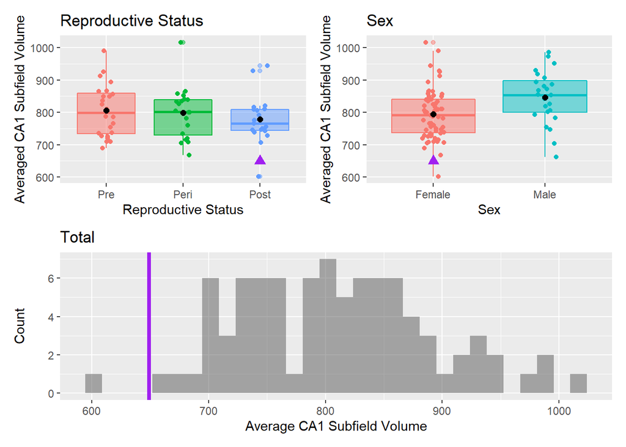

### Hormone Correlation by Reproductive Status

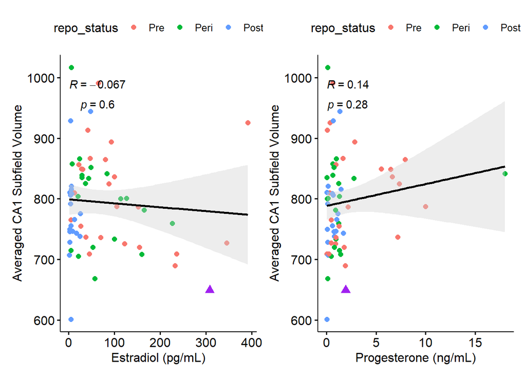

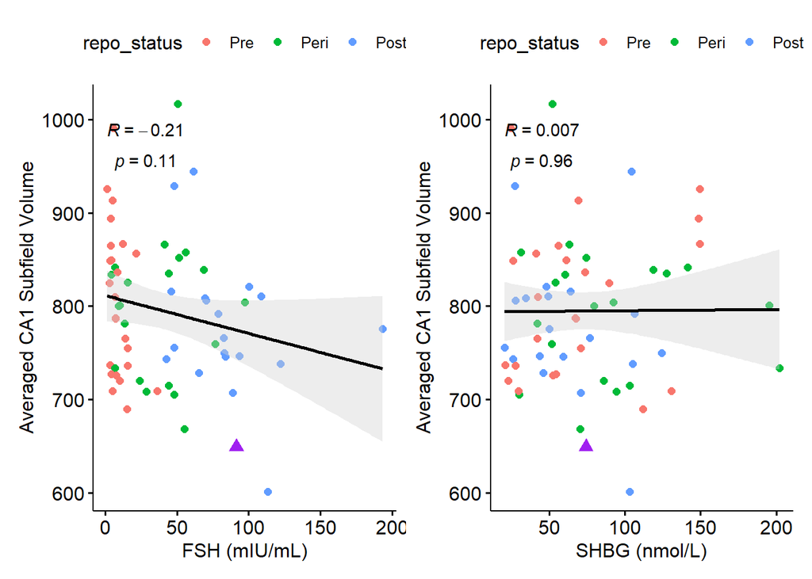

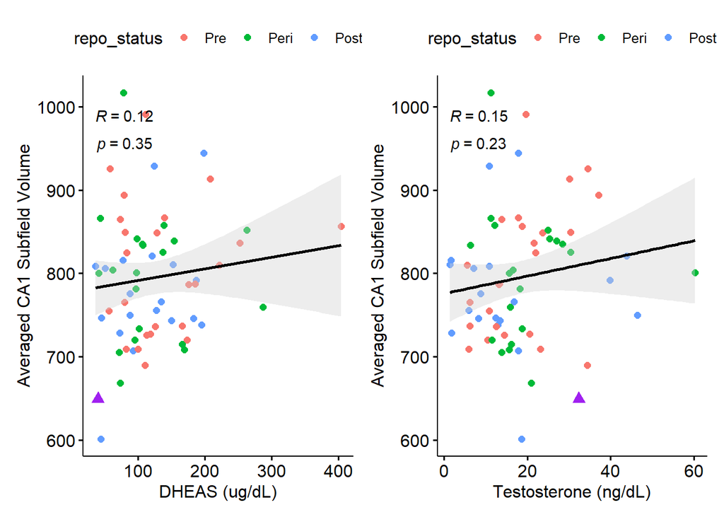

### Hormone Correlation by Reproductive Sex

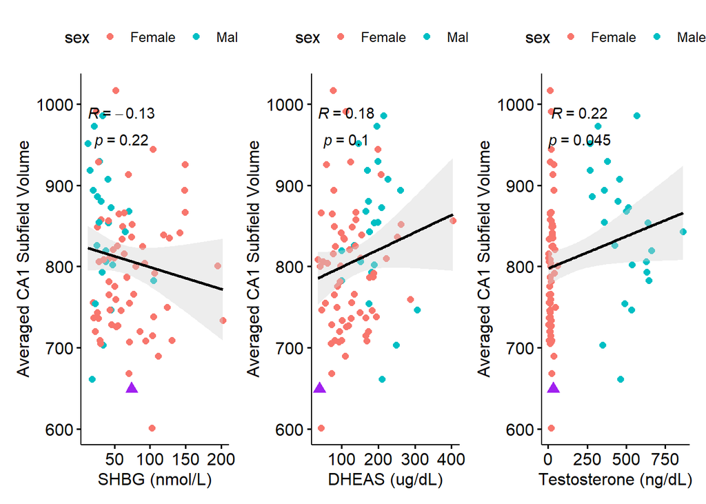

## CA2/3

Subject 438: average volume of 242.462

### Structural Comparison

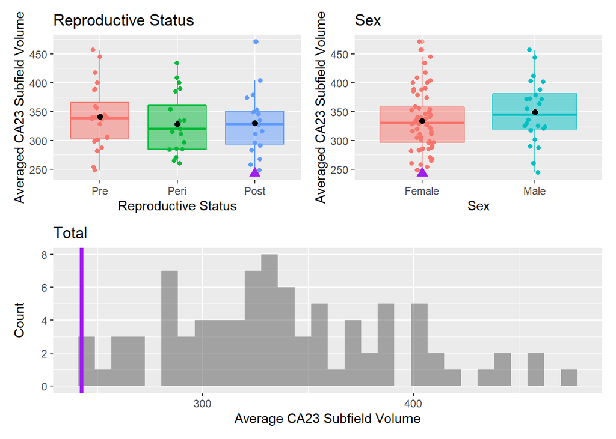

### Hormone Correlation by Reproductive Status

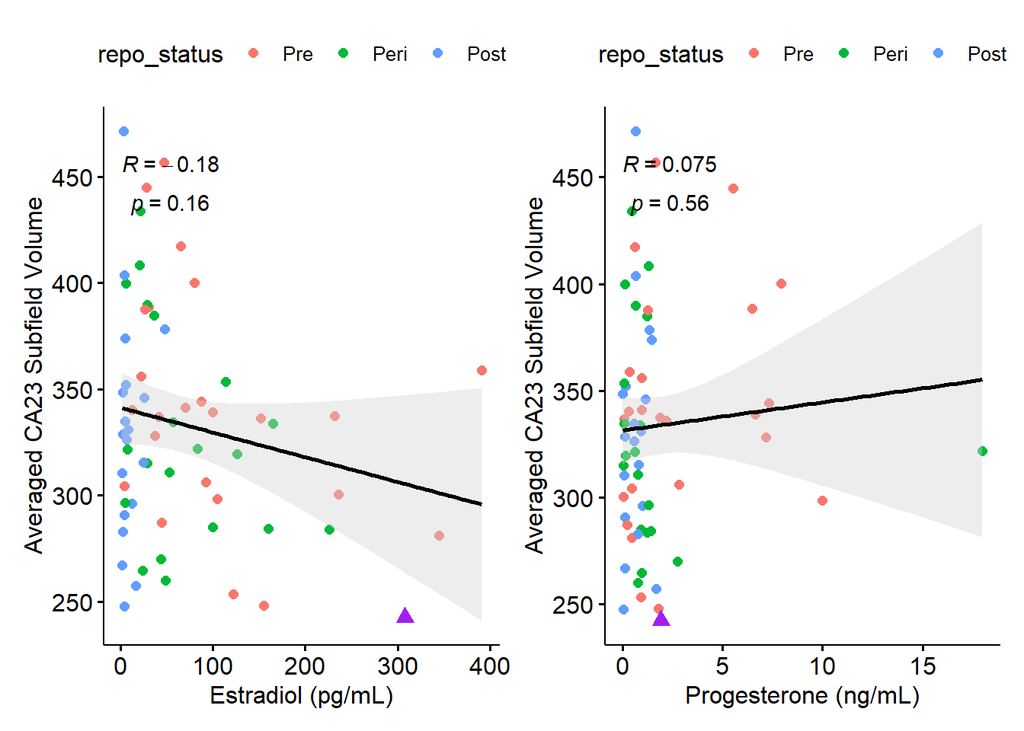

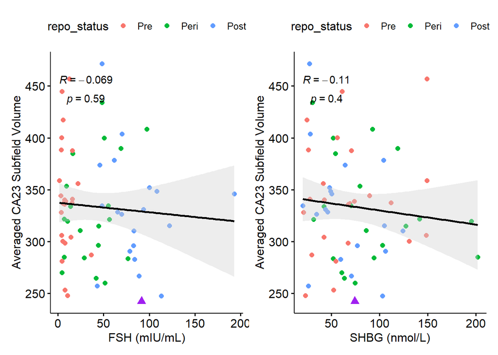

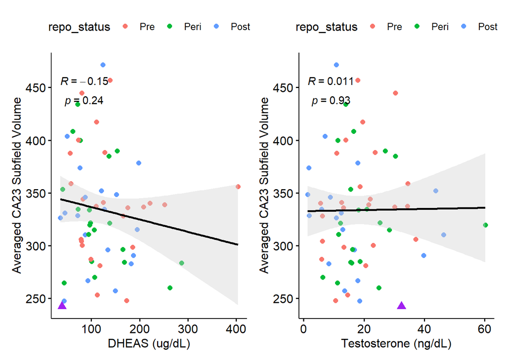

### Hormone Correlation by Reproductive Sex

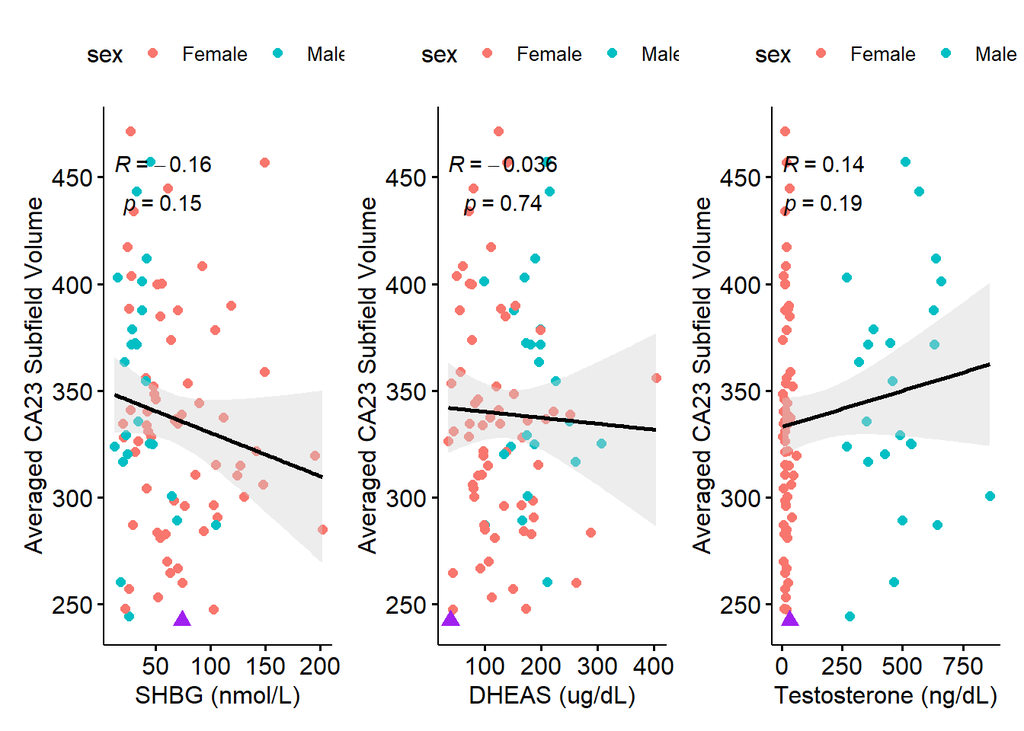

## DG

Subject 438: average volume of 724.0295

### Structural Comparison

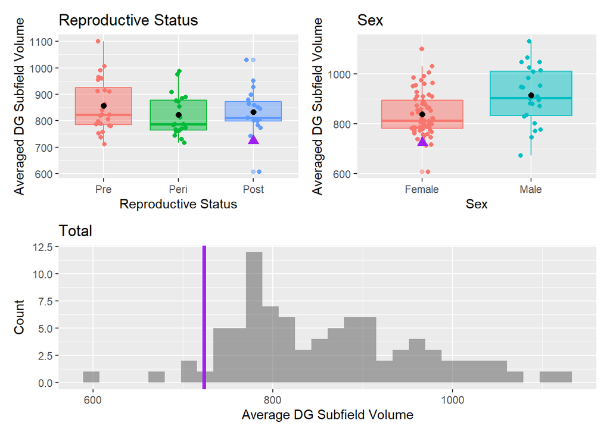

### Hormone Correlation by Reproductive Status

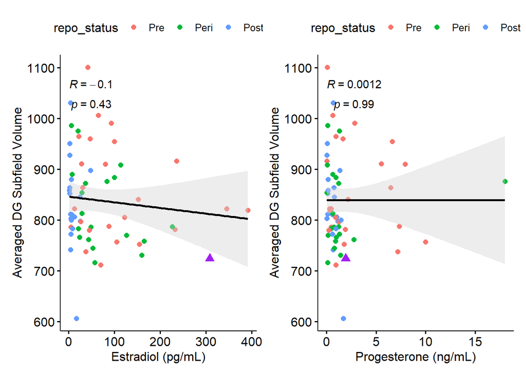

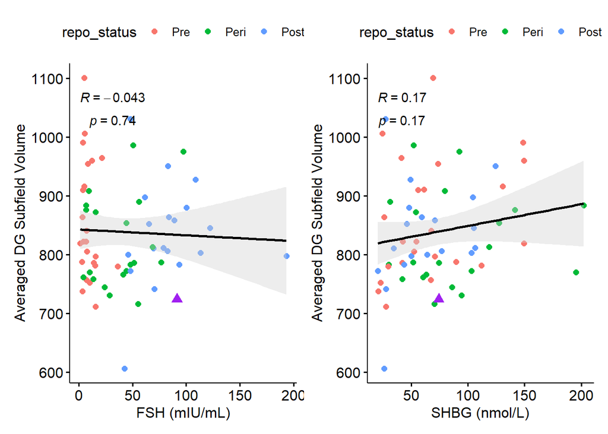

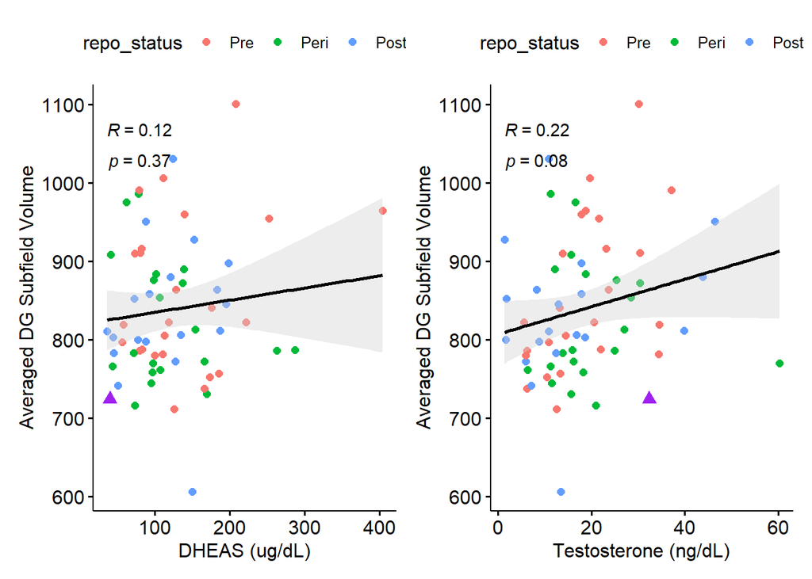

### Hormone Correlation by Reproductive Sex

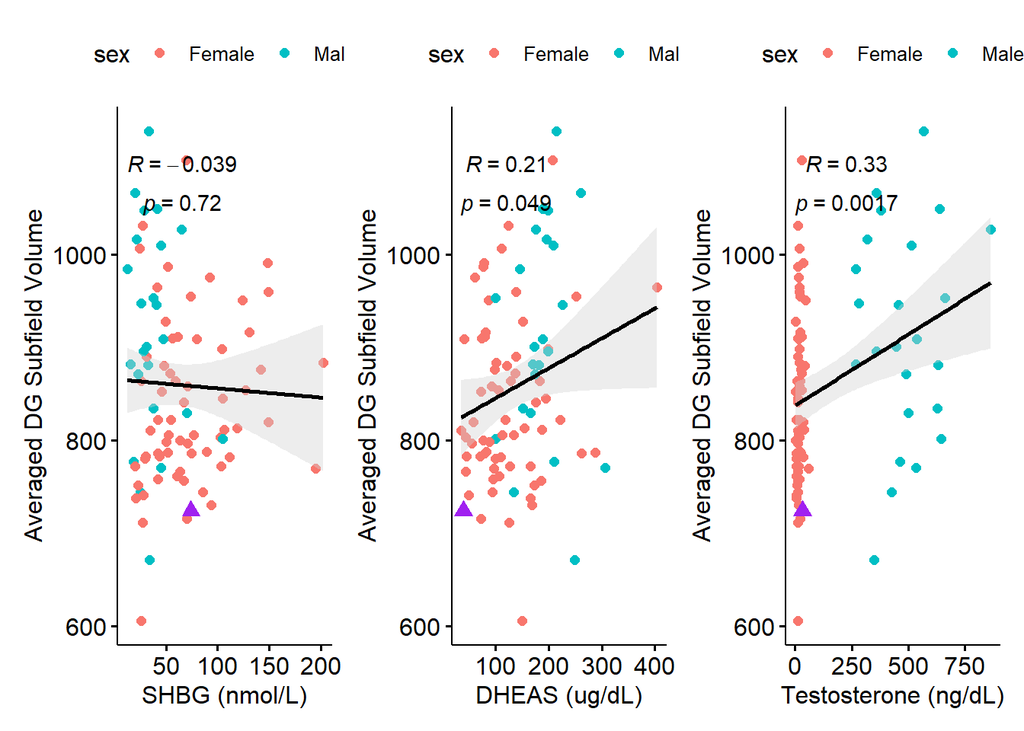

## ERC

Subject 438: average volume of 1117.86

### Structural Comparison

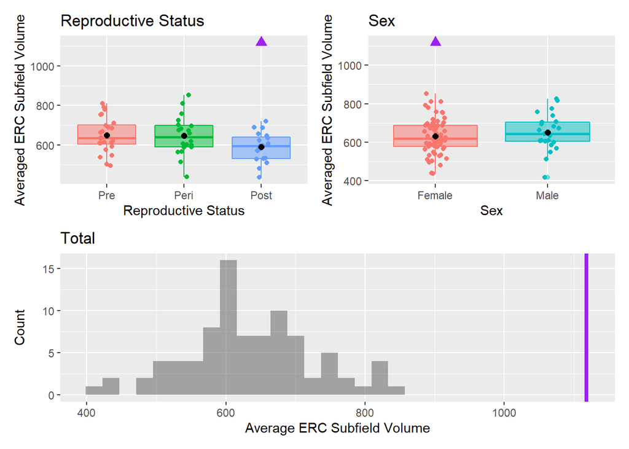

### Hormone Correlation by Reproductive Status

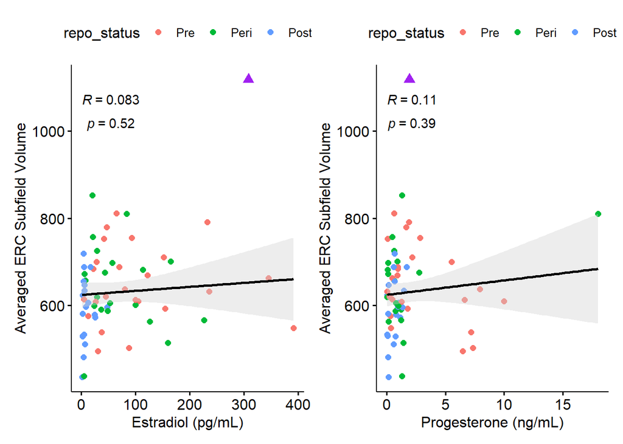

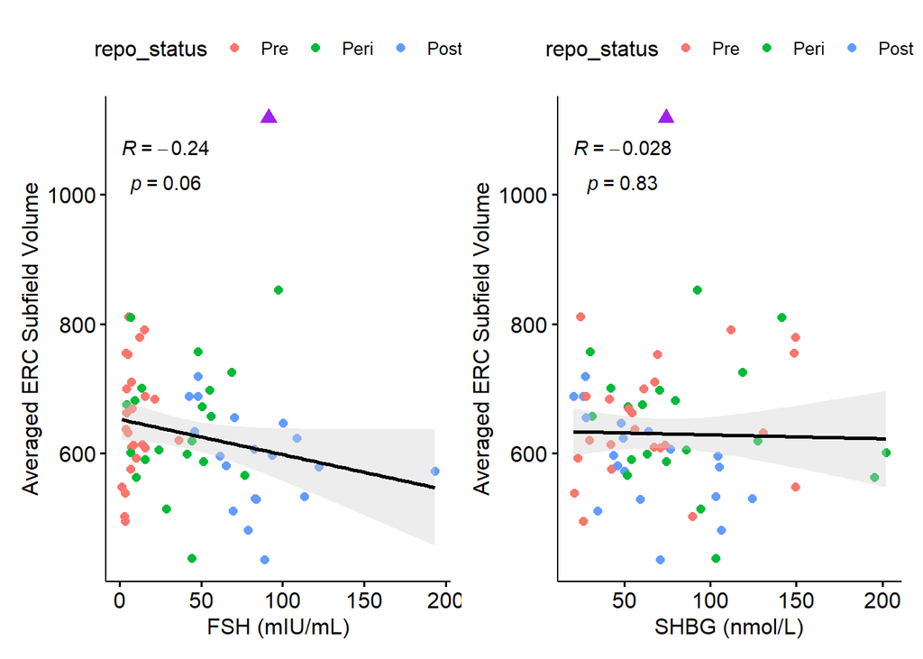

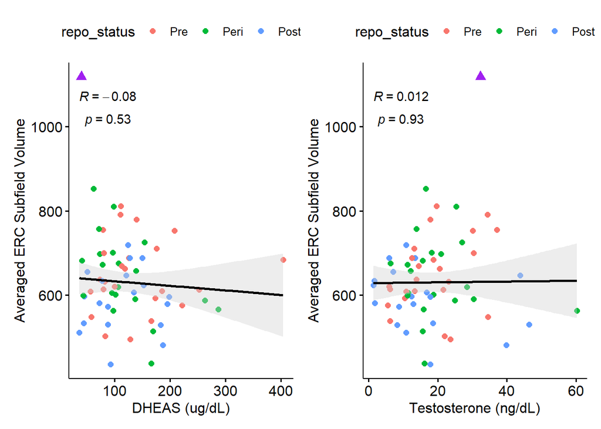

### Hormone Correlation by Reproductive Sex

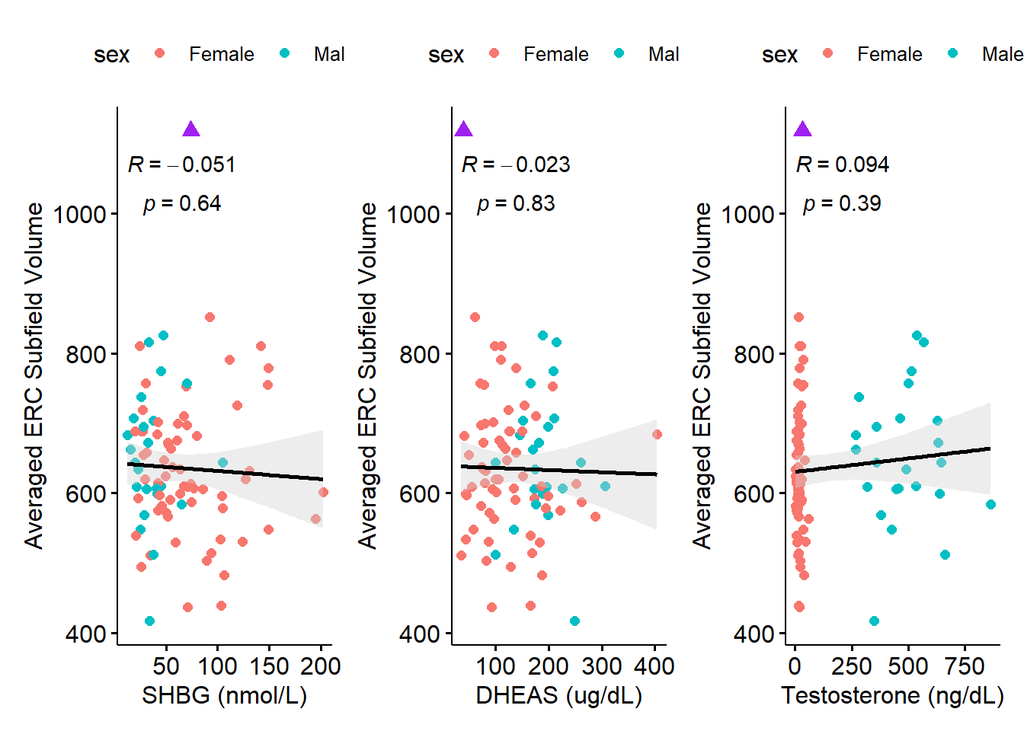

## PHC

Subject 438: average volume of 2061.765

### Structural Comparison

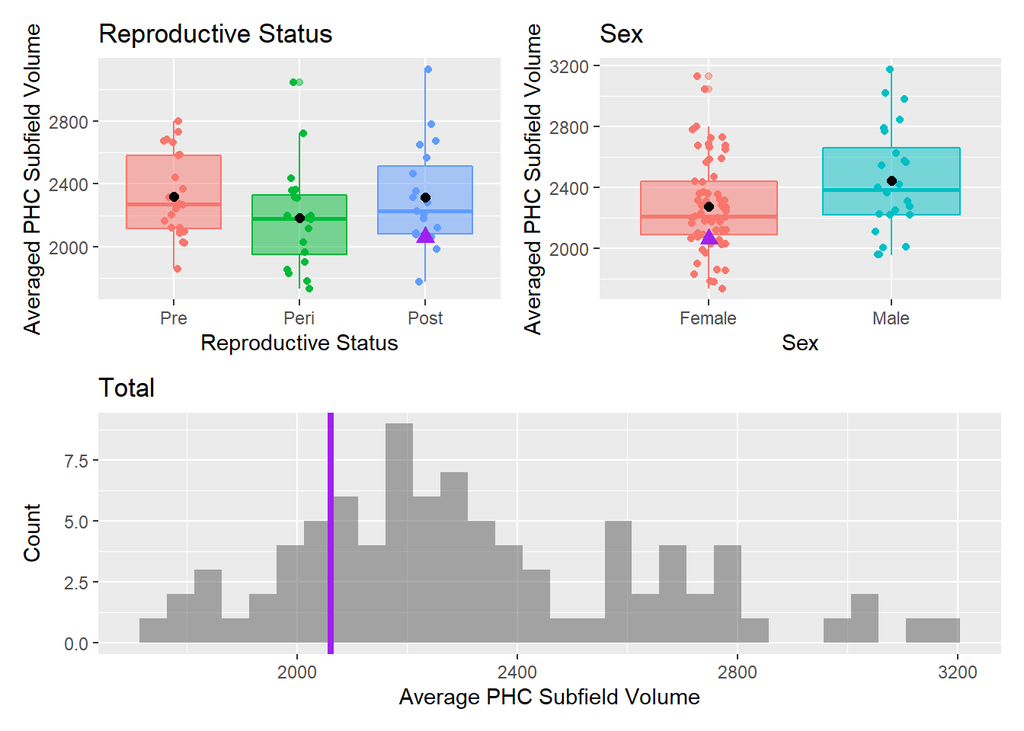

### Hormone Correlation by Reproductive Status

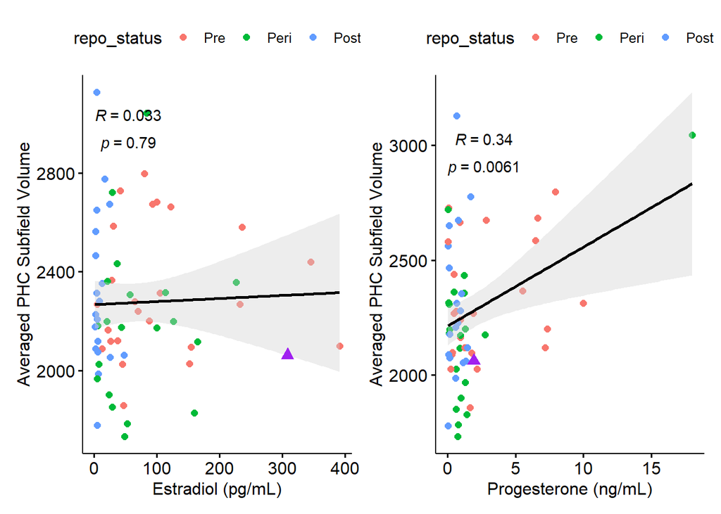

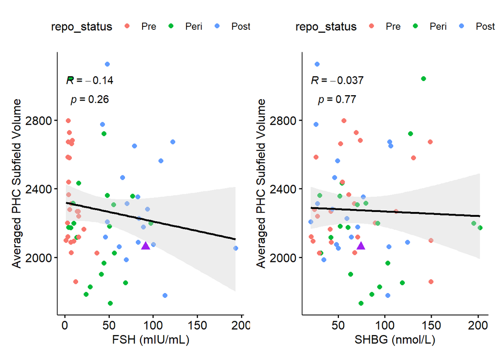

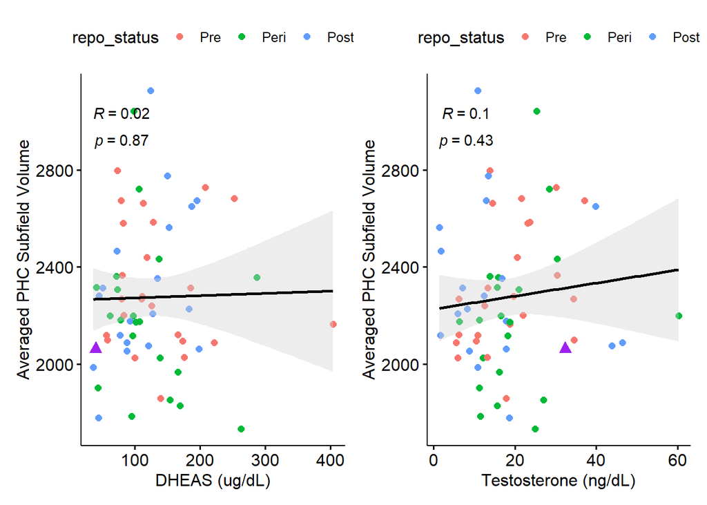

### Hormone Correlation by Reproductive Sex

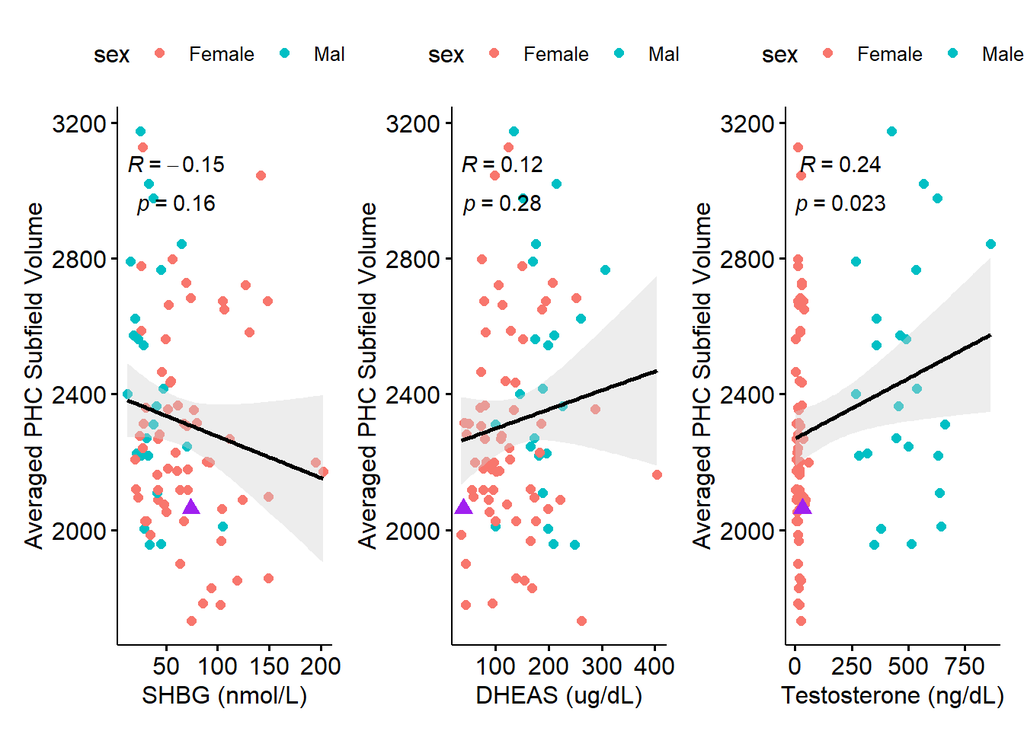

## PRC

Subject 438: average volume of 1871.035

### Structural Comparison

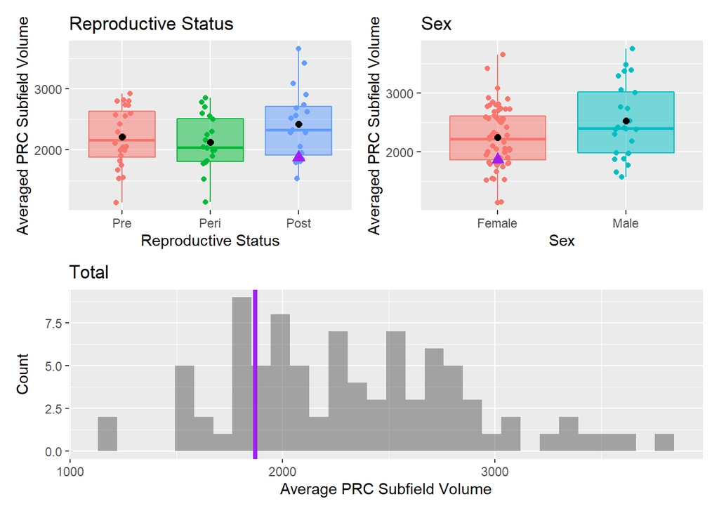

### Hormone Correlation by Reproductive Status

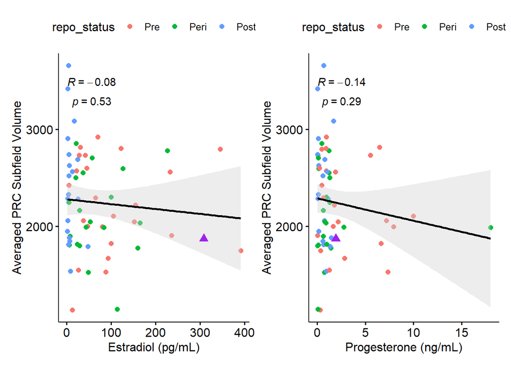

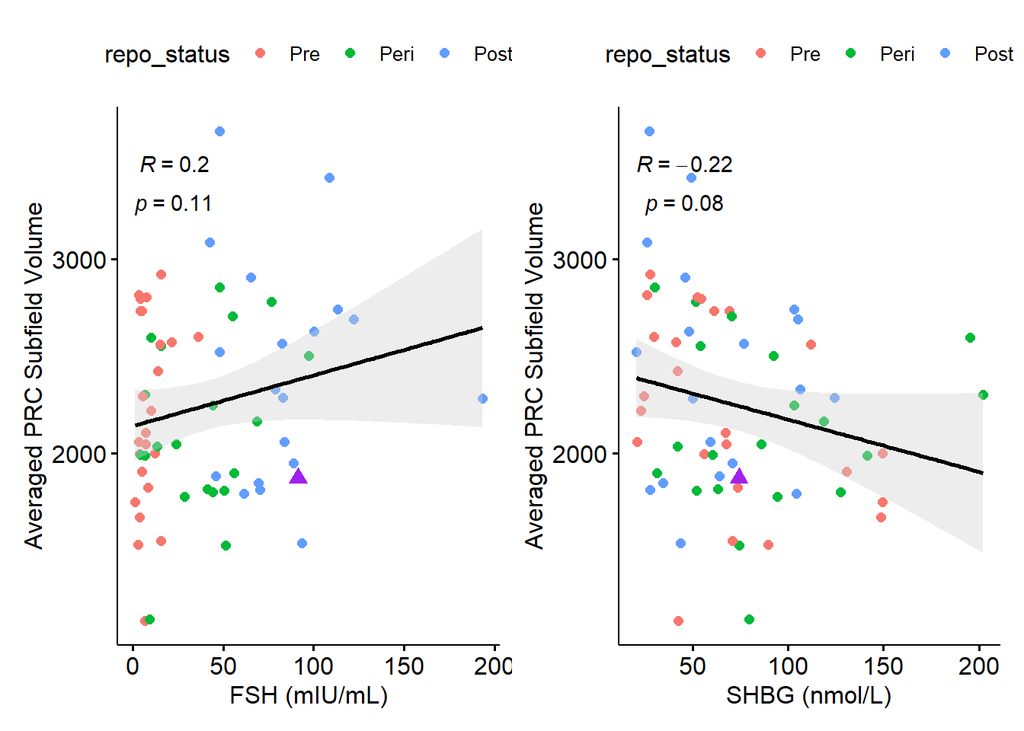

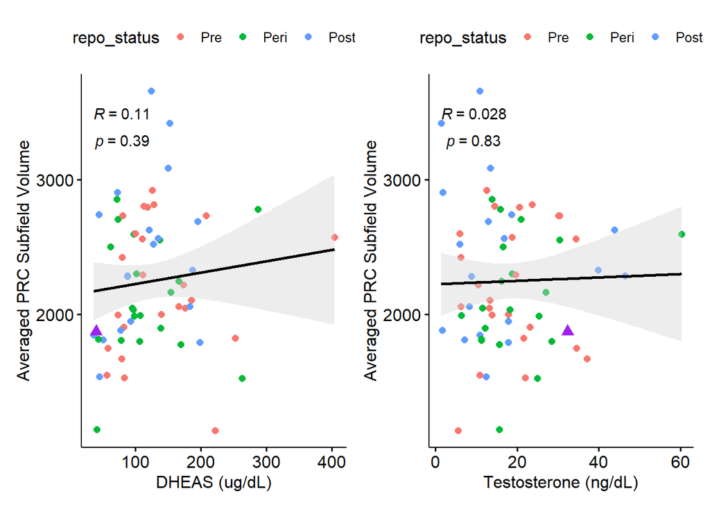

### Hormone Correlation by Reproductive Sex

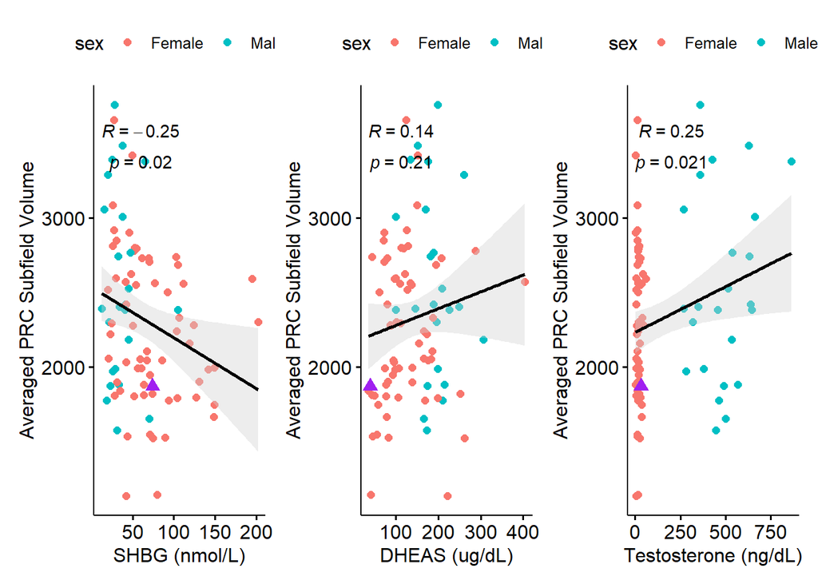

## SUB

Subject 438: average volume of 352.936

### Structural Comparison

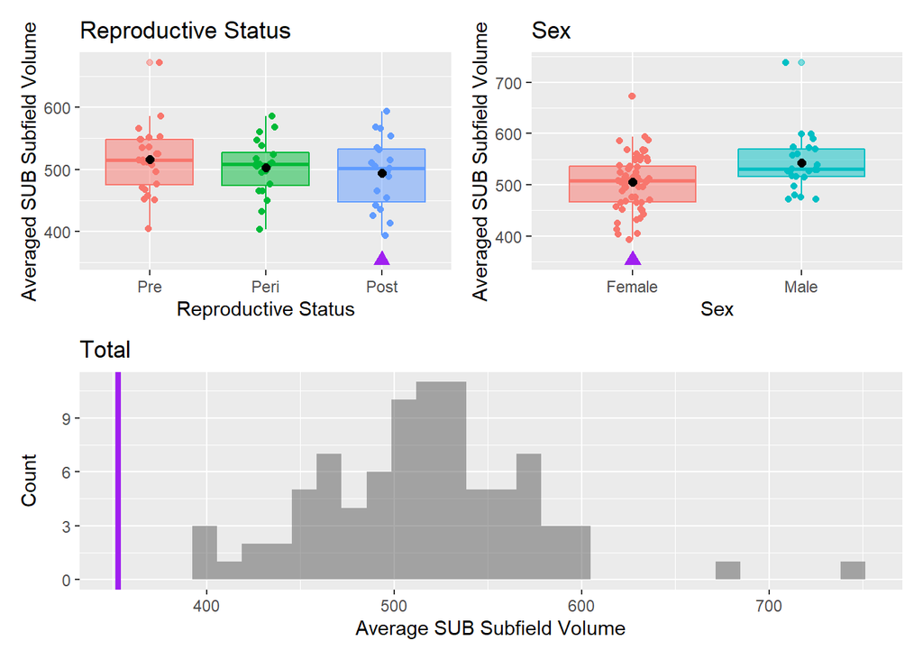